# Imtiaz Miah’s Enzyme Data Processing and Analysis

Erin C Rooney

2023-03-30

# Enzyme Data

### All data belongs to PhIr Project/Imtiaz Miah

**step 1: load packages for analysis**

You can remove packages that you don’t need, and you may need to load some (which can be done by going to packages, clicking “install” and then typing in the name of the package you need.) You only need to install once, but everytime you restart R, then you need to call the package via the command “library”. This can be done by just running line 23 below, which runs your full packages script.

```r
knitr::opts_chunk$set(echo = TRUE)

source("code/0-packages_im.R")
```

**step 2: load data**

load data from years 2021 and 2022

```r
enzymes2022 = read.csv("raw/Miah_enzymes_2022.csv")
head(enzymes2022)
```

```
##          date  sample  site soil_layer dry_wet       BG        LAP   NAG
## 1 27-Jul-2018 East D1   Dry    Organic  0.3734  9661.26   0.000001 1e-06
## 2 27-Jul-2018 East D2   Dry    Organic  0.3666  7663.13   0.000001 1e-06
## 3 27-Jul-2018 East D3   Dry    Organic  0.3688  6997.15   0.000001 1e-06
## 4 27-Jul-2018 East M1 Mesic    Organic  0.2236 18091.58   0.000001 1e-06
## 5 27-Jul-2018 East M2 Mesic    Organic  0.2028 23590.07 234.410000 1e-06
## 6 27-Jul-2018 East M3 Mesic    Organic  0.1606 13304.47  61.590000 1e-06
##       PHOS
## 1 10238.70
## 2 31626.47
## 3 28580.70
## 4 25909.98
## 5 49481.92
## 6 64189.91
```

```r
enzymes2021 = read.csv("raw/Miah_enzymes2021.csv")
head(enzymes2021)
```

```
##       date  sample  site soil_layer dry_wet      BG        LAP     NAG     PHOS
## 1 1-Jul-17 East D1   Dry    Organic  0.1374 3492.13  49.850000 7107.72       NA
## 2 1-Jul-17 East D2   Dry    Organic  0.1642 3724.92   0.000001 6936.62 12385.15
## 3 1-Jul-17 East D3   Dry    Organic  0.1494      NA   0.000001      NA  9135.40
## 4 1-Jul-17 East M1 Mesic    Organic  0.1612      NA 100.820000      NA 15542.03
## 5 1-Jul-17 East M2 Mesic    Organic  0.1806 3024.66 194.580000 5199.51 11689.87
## 6 1-Jul-17 East M3 Mesic    Organic  0.1570 3344.38 114.760000 4012.22       NA
```

**step 3: data cleaning**

Here we are redoing the date so that it will be more friendly to work with later. We’re adding the year so that both 2021 and 2022 datasets can be combined (eventually). We’re also setting some factors and ordering variables within columns so that they make sense (dry goes first, then mesic, then hydric, or organic before mineral, etc. )

```r
enzymes2022_fixed =
  enzymes2022 %>%
  separate(date, sep = "-", into = c("day", "month", "year")) %>%
  mutate(day = as.numeric(day)) %>%
  mutate(day = (day + 1)) %>%
  dplyr::select(-year) %>%
  mutate(year = 2022) %>%
  mutate(year = factor(year, levels = c("2021", "2022"))) %>%
  mutate(soil_layer = factor(soil_layer, levels = c("Organic", "Mineral"))) %>%
  separate(sample, sep = " ", into = c("area", "plot")) %>%
  dplyr::mutate(plotnum = case_when(grepl("1", plot)~"1",
                                  grepl("2", plot)~"2",
                                  grepl("3", plot)~"3")) %>%
  mutate(site = factor(site, levels = c("Dry", "Mesic", "Hydric")))

head(enzymes2022_fixed)
```

```
##   day month area plot  site soil_layer dry_wet       BG        LAP   NAG
## 1  28   Jul East   D1   Dry    Organic  0.3734  9661.26   0.000001 1e-06
## 2  28   Jul East   D2   Dry    Organic  0.3666  7663.13   0.000001 1e-06
## 3  28   Jul East   D3   Dry    Organic  0.3688  6997.15   0.000001 1e-06
## 4  28   Jul East   M1 Mesic    Organic  0.2236 18091.58   0.000001 1e-06
## 5  28   Jul East   M2 Mesic    Organic  0.2028 23590.07 234.410000 1e-06
## 6  28   Jul East   M3 Mesic    Organic  0.1606 13304.47  61.590000 1e-06
##       PHOS year plotnum
## 1 10238.70 2022       1
## 2 31626.47 2022       2
## 3 28580.70 2022       3
## 4 25909.98 2022       1
## 5 49481.92 2022       2
## 6 64189.91 2022       3
```

```r
enzymes2021_fixed =
  enzymes2021 %>%
  separate(date, sep = "-", into = c("day", "month", "year")) %>%
  mutate(day = as.numeric(day)) %>%
  mutate(day = (day + 1)) %>%
  dplyr::select(-year) %>%
  mutate(year = 2021) %>%
  mutate(year = factor(year, levels = c("2021", "2022"))) %>%
  mutate(soil_layer = factor(soil_layer, levels = c("Organic", "Mineral"))) %>%
  separate(sample, sep = " ", into = c("area", "plot")) %>%
  dplyr::mutate(plotnum = case_when(grepl("1", plot)~"1",
                                    grepl("2", plot)~"2",
                                    grepl("3", plot)~"3")) %>%
  mutate(site = factor(site, levels = c("Dry", "Mesic", "Hydric")))
  #filter(month == "Aug")

head(enzymes2021_fixed)
```

```
##   day month area plot  site soil_layer dry_wet      BG        LAP     NAG
## 1   2   Jul East   D1   Dry    Organic  0.1374 3492.13  49.850000 7107.72
## 2   2   Jul East   D2   Dry    Organic  0.1642 3724.92   0.000001 6936.62
## 3   2   Jul East   D3   Dry    Organic  0.1494      NA   0.000001      NA
## 4   2   Jul East   M1 Mesic    Organic  0.1612      NA 100.820000      NA
## 5   2   Jul East   M2 Mesic    Organic  0.1806 3024.66 194.580000 5199.51
## 6   2   Jul East   M3 Mesic    Organic  0.1570 3344.38 114.760000 4012.22
##       PHOS year plotnum
## 1       NA 2021       1
## 2 12385.15 2021       2
## 3  9135.40 2021       3
## 4 15542.03 2021       1
## 5 11689.87 2021       2
## 6       NA 2021       3
```

**step 4: data organization**

Here we’re just exploring different ways to organize the data, such as:

- Making the data longer (all enzyme types in one column with enzyme activity in a second column)
- Making the data wider (each enzyme type and associated activity has two columns, so more columns total)

```r
enzymes2022_fixed_longer =
  enzymes2022_fixed %>%
  pivot_longer(-c(day, month, year, plot, plotnum, site, area, soil_layer, dry_wet),
               names_to = "enzyme_type", values_to = "enzyme_activity")

head(enzymes2022_fixed_longer)
```

```
## # A tibble: 6 x 11
##     day month area  plot  site  soil_layer dry_wet year  plotnum enzym~1 enzym~2
##   <dbl> <chr> <chr> <chr> <fct> <fct>        <dbl> <fct> <chr>   <chr>     <dbl>
## 1    28 Jul   East  D1    Dry   Organic      0.373 2022  1       BG      9.66e+3
## 2    28 Jul   East  D1    Dry   Organic      0.373 2022  1       LAP     1   e-6
## 3    28 Jul   East  D1    Dry   Organic      0.373 2022  1       NAG     1   e-6
## 4    28 Jul   East  D1    Dry   Organic      0.373 2022  1       PHOS    1.02e+4
## 5    28 Jul   East  D2    Dry   Organic      0.367 2022  2       BG      7.66e+3
## 6    28 Jul   East  D2    Dry   Organic      0.367 2022  2       LAP     1   e-6
## # ... with abbreviated variable names 1: enzyme_type, 2: enzyme_activity
```

```r
enzymes2021_fixed_longer =
  enzymes2021_fixed %>%
  pivot_longer(-c(day, month, year, plot, plotnum, site, area, soil_layer, dry_wet),
               names_to = "enzyme_type", values_to = "enzyme_activity")

head(enzymes2021_fixed_longer)
```

```
## # A tibble: 6 x 11
##     day month area  plot  site  soil_la~1 dry_wet year  plotnum enzym~2 enzyme~3
##   <dbl> <chr> <chr> <chr> <fct> <fct>       <dbl> <fct> <chr>   <chr>      <dbl>
## 1     2 Jul   East  D1    Dry   Organic     0.137 2021  1       BG       3.49e+3
## 2     2 Jul   East  D1    Dry   Organic     0.137 2021  1       LAP      4.99e+1
## 3     2 Jul   East  D1    Dry   Organic     0.137 2021  1       NAG      7.11e+3
## 4     2 Jul   East  D1    Dry   Organic     0.137 2021  1       PHOS    NA
## 5     2 Jul   East  D2    Dry   Organic     0.164 2021  2       BG       3.72e+3
## 6     2 Jul   East  D2    Dry   Organic     0.164 2021  2       LAP      1   e-6
## # ... with abbreviated variable names 1: soil_layer, 2: enzyme_type,
## #   3: enzyme_activity
```

Now we’re combining the dataframes from 2021 and 2022 together

```r
all_enzymes_longer =
  enzymes2022_fixed_longer %>%
  vctrs::vec_c(enzymes2021_fixed_longer) %>%
  group_by(year, day, site, area, plot, soil_layer, enzyme_type) %>%
  dplyr::mutate(n = n())

head(all_enzymes_longer)
```

```
## # A tibble: 6 x 12
## # Groups:   year, day, site, area, plot, soil_layer, enzyme_type [6]
##     day month area  plot  site  soil_layer dry_wet year  plotnum enzym~1 enzym~2
##   <dbl> <chr> <chr> <chr> <fct> <fct>        <dbl> <fct> <chr>   <chr>     <dbl>
## 1    28 Jul   East  D1    Dry   Organic      0.373 2022  1       BG      9.66e+3
## 2    28 Jul   East  D1    Dry   Organic      0.373 2022  1       LAP     1   e-6
## 3    28 Jul   East  D1    Dry   Organic      0.373 2022  1       NAG     1   e-6
## 4    28 Jul   East  D1    Dry   Organic      0.373 2022  1       PHOS    1.02e+4
## 5    28 Jul   East  D2    Dry   Organic      0.367 2022  2       BG      7.66e+3
## 6    28 Jul   East  D2    Dry   Organic      0.367 2022  2       LAP     1   e-6
## # ... with 1 more variable: n <int>, and abbreviated variable names
## #   1: enzyme_type, 2: enzyme_activity
## # i Use `colnames()` to see all variable names
```

And we can make the combined dataframes back into a wider format

```r
all_enzymes_wider =
  enzymes2022_fixed_longer %>%
  vctrs::vec_c(enzymes2021_fixed_longer) %>%
  group_by(year, day, site, area, plot, soil_layer, enzyme_type) %>%
  pivot_wider(names_from = 'enzyme_type', values_from = "enzyme_activity")

head(all_enzymes_wider)
```

```
## # A tibble: 6 x 13
## # Groups:   year, day, site, area, plot, soil_layer [6]
##     day month area  plot  site  soil_layer dry_wet year  plotnum     BG      LAP
##   <dbl> <chr> <chr> <chr> <fct> <fct>        <dbl> <fct> <chr>    <dbl>    <dbl>
## 1    28 Jul   East  D1    Dry   Organic      0.373 2022  1        9661.  1   e-6
## 2    28 Jul   East  D2    Dry   Organic      0.367 2022  2        7663.  1   e-6
## 3    28 Jul   East  D3    Dry   Organic      0.369 2022  3        6997.  1   e-6
## 4    28 Jul   East  M1    Mesic Organic      0.224 2022  1       18092.  1   e-6
## 5    28 Jul   East  M2    Mesic Organic      0.203 2022  2       23590.  2.34e+2
## 6    28 Jul   East  M3    Mesic Organic      0.161 2022  3       13304.  6.16e+1
## # ... with 2 more variables: NAG <dbl>, PHOS <dbl>
## # i Use `colnames()` to see all variable names
```

When we were working on figures together, we makes some specialized dataframes that we need for figures, so I’ll include these below as well.

```r
all_enzymes_wider_2021 =
  enzymes2021_fixed_longer %>%
  group_by(year, day, site, area, plot, soil_layer, enzyme_type) %>%
  pivot_wider(names_from = 'enzyme_type', values_from = "enzyme_activity") %>%
  mutate(month = recode(month, "Aug" = "August", "Jul" = "July")) %>%
  #dplyr::mutate(date = as.Date(paste(year, month, day, sep = "-"))) %>%
  mutate(date = paste(month, day, sep = " ")) %>%
  mutate(date = factor(date, levels = c("July 2", "July 5", "July 20",
                                        "July 23", "August 3", "August 6"))) %>%
  filter(soil_layer == "Organic")

head(all_enzymes_wider_2021)
```

```
## # A tibble: 6 x 14
## # Groups:   year, day, site, area, plot, soil_layer [6]
##     day month area  plot  site  soil_layer dry_wet year  plotnum    BG       LAP
##   <dbl> <chr> <chr> <chr> <fct> <fct>        <dbl> <fct> <chr>   <dbl>     <dbl>
## 1     2 July  East  D1    Dry   Organic      0.137 2021  1       3492.   4.99e+1
## 2     2 July  East  D2    Dry   Organic      0.164 2021  2       3725.   1   e-6
## 3     2 July  East  D3    Dry   Organic      0.149 2021  3         NA    1   e-6
## 4     2 July  East  M1    Mesic Organic      0.161 2021  1         NA    1.01e+2
## 5     2 July  East  M2    Mesic Organic      0.181 2021  2       3025.   1.95e+2
## 6     2 July  East  M3    Mesic Organic      0.157 2021  3       3344.   1.15e+2
## # ... with 3 more variables: NAG <dbl>, PHOS <dbl>, date <fct>
## # i Use `colnames()` to see all variable names
```

```r
all_enzymes_notwider_2021 =
  enzymes2021_fixed_longer %>%
  #group_by(year, day, site, area, plot, soil_layer, enzyme_type) %>%
  #pivot_wider(names_from = 'enzyme_type', values_from = "enzyme_activity") %>%
  mutate(month = recode(month, "Aug" = "August", "Jul" = "July")) %>%
  #dplyr::mutate(date = as.Date(paste(year, month, day, sep = "-"))) %>%
  mutate(date = paste(month, day, sep = " ")) %>%
  mutate(date = factor(date, levels = c("July 2", "July 5", "July 20",
                                        "July 23", "August 3", "August 6"))) %>%
  filter(soil_layer == "Organic")

head(all_enzymes_notwider_2021)
```

```
## # A tibble: 6 x 12
##     day month area  plot  site  soil_la~1 dry_wet year  plotnum enzym~2 enzyme~3
##   <dbl> <chr> <chr> <chr> <fct> <fct>       <dbl> <fct> <chr>   <chr>      <dbl>
## 1     2 July  East  D1    Dry   Organic     0.137 2021  1       BG       3.49e+3
## 2     2 July  East  D1    Dry   Organic     0.137 2021  1       LAP      4.99e+1
## 3     2 July  East  D1    Dry   Organic     0.137 2021  1       NAG      7.11e+3
## 4     2 July  East  D1    Dry   Organic     0.137 2021  1       PHOS    NA
## 5     2 July  East  D2    Dry   Organic     0.164 2021  2       BG       3.72e+3
## 6     2 July  East  D2    Dry   Organic     0.164 2021  2       LAP      1   e-6
## # ... with 1 more variable: date <fct>, and abbreviated variable names
## #   1: soil_layer, 2: enzyme_type, 3: enzyme_activity
## # i Use `colnames()` to see all variable names
```

**step 5: export cleaned and organized data**

You can pick the file path. Generally, I like to have a common folder organization with code, raw_data, processed_data, and output folders.

```r
#export csv file
write.csv(all_enzymes_longer, "output/all_enzymes_longer.csv")

write.csv(all_enzymes_wider, "output/all_enzymes_wider.csv")
```

**step 6: data visualization**

Boxplots!

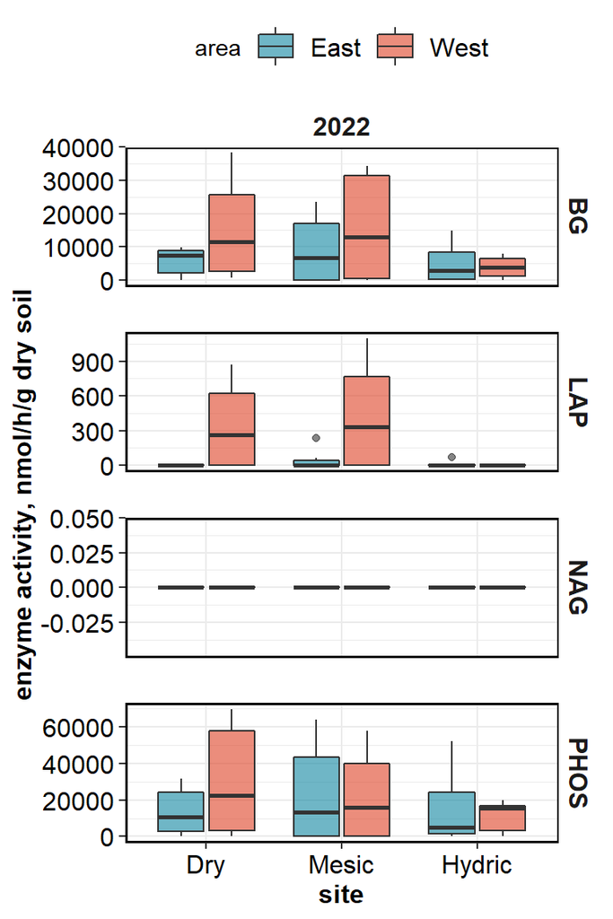

```r
all2022_data =
  all_enzymes_longer %>%
  filter(year == 2022) %>%
  ggplot(aes(x = site, y = enzyme_activity, fill = area))+
  geom_boxplot(alpha = 0.6)+
  labs(y = "enzyme activity, nmol/h/g dry soil",
       x = "site")+
  scale_fill_manual(values = (PNWColors::pnw_palette("Bay", 2)))+
  facet_grid(enzyme_type~year, scales = "free_y")+
  theme_im()

plot(all2022_data)
```

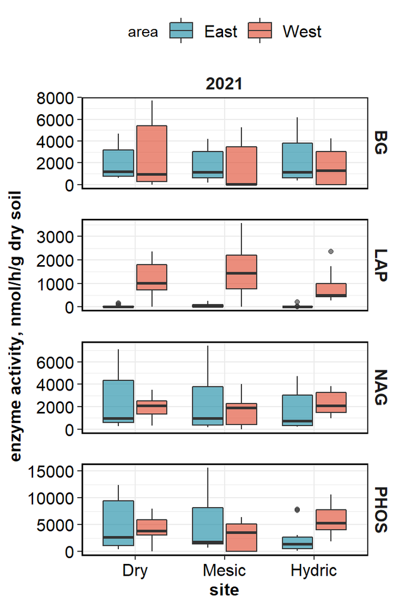

```r
ggsave("output/boxplot_all2022_data.png",  plot = all2022_data, width = 4, height = 6)


all2021_data =
  all_enzymes_longer %>%
  filter(year == 2021) %>%
  ggplot(aes(x = site, y = enzyme_activity, fill = area))+
  geom_boxplot(alpha = 0.6)+
  labs(y = "enzyme activity, nmol/h/g dry soil",
       x = "site")+
  scale_fill_manual(values = (PNWColors::pnw_palette("Bay", 2)))+
  facet_grid(enzyme_type~year, scales = "free_y")+
  theme_im()

plot(all2021_data)
```

```r
ggsave("output/boxplot_all2021_data.png",  plot = all2021_data, width = 4, height = 6)
```

Mineral vs Organic plots

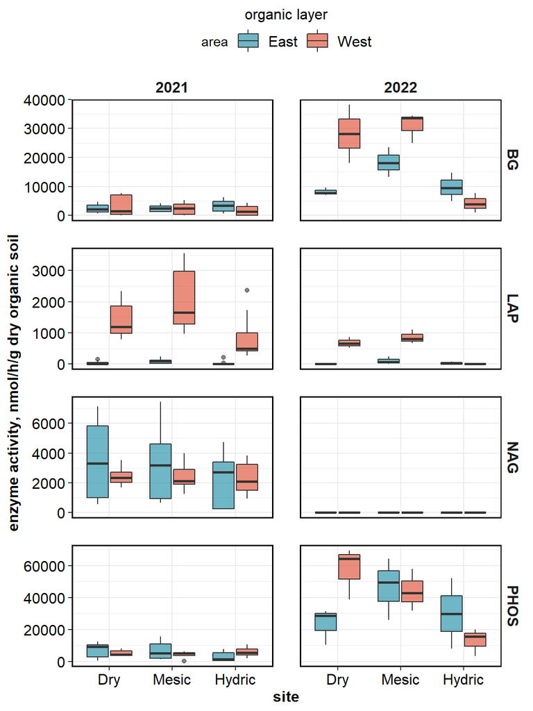

```r
boxplot_organic =
  all_enzymes_longer %>%
  filter(soil_layer == "Organic") %>%
  ggplot(aes(x = site, y = enzyme_activity, fill = area))+
  geom_boxplot(alpha = 0.6)+
  labs(y = "enzyme activity, nmol/h/g dry organic soil",
       x = "site",
       subtitle = "organic layer")+
  scale_fill_manual(values = (PNWColors::pnw_palette("Bay", 2)))+
  facet_grid(enzyme_type~year, scales = "free_y")+
  theme_im()

plot(boxplot_organic)
```

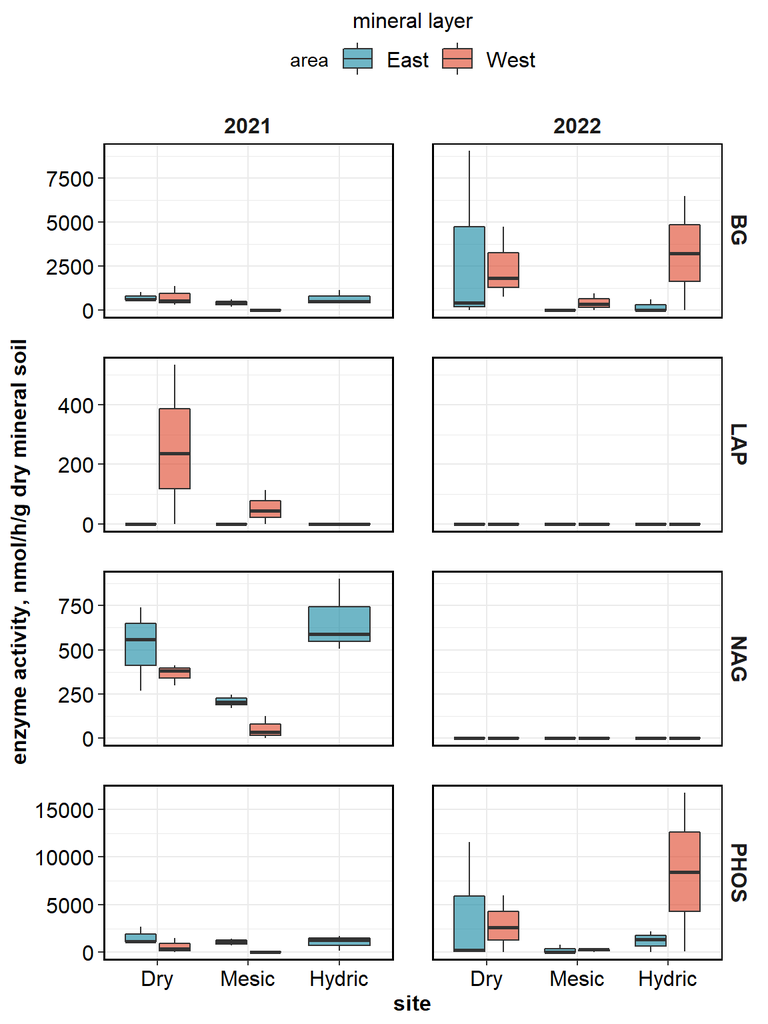

```r
ggsave("output/boxplot_organic.png",  plot = boxplot_organic, width = 6, height = 8)
boxplot_mineral =
  all_enzymes_longer %>%
  filter(soil_layer == "Mineral") %>%
  ggplot(aes(x = site, y = enzyme_activity, fill = area))+
  geom_boxplot(alpha = 0.6)+
  labs(y = "enzyme activity, nmol/h/g dry mineral soil",
       x = "site",
       subtitle = "mineral layer")+
  scale_fill_manual(values = (PNWColors::pnw_palette("Bay", 2)))+
  facet_grid(enzyme_type~year, scales = "free_y")+
  theme_im()

plot(boxplot_mineral)
```

```r
ggsave("output/boxplot_mineral.png",  plot = boxplot_mineral, width = 6, height = 8)
```

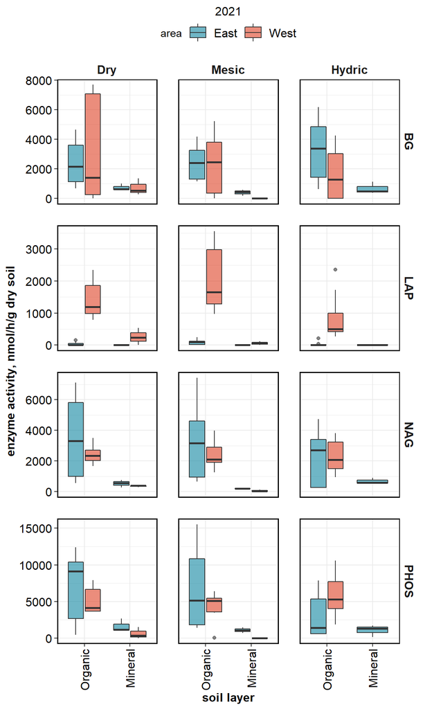

```r
boxplot_2021bysoillayer =
  all_enzymes_longer %>%
  filter(year == "2021") %>%
  ggplot(aes(x = soil_layer, y = enzyme_activity, fill = area))+
  geom_boxplot(alpha = 0.6)+
  labs(y = "enzyme activity, nmol/h/g dry soil",
       x = "soil layer",
       subtitle = "2021")+
  facet_grid(enzyme_type~site, scales = "free_y")+
  scale_fill_manual(values = (PNWColors::pnw_palette("Bay", 2)))+
  theme_im()+
  theme(axis.text.x = element_text(angle = 90, vjust = 0.5, hjust=1))

plot(boxplot_2021bysoillayer)
```

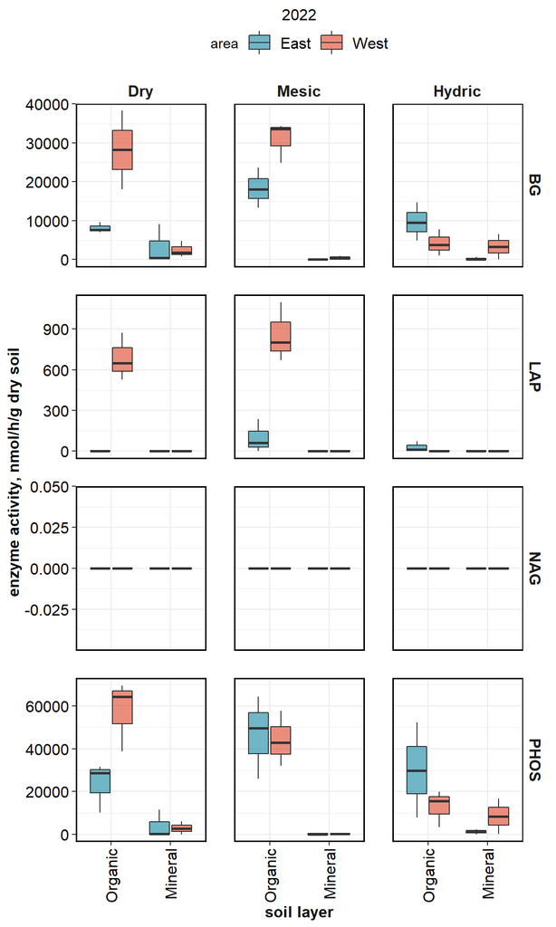

```r
ggsave("output/boxplot_2021_soillayers.png",  plot = boxplot_2021bysoillayer, width = 6, height = 10)
boxplot_2022bysoillayer =
all_enzymes_longer %>%
  filter(year == "2022") %>%
  ggplot(aes(x = soil_layer, y = enzyme_activity, fill = area))+
  geom_boxplot(alpha = 0.6)+
  labs(y = "enzyme activity, nmol/h/g dry soil",
       x = "soil layer",
       subtitle = "2022")+
  facet_grid(enzyme_type~site, scales = "free_y")+
  scale_fill_manual(values = (PNWColors::pnw_palette("Bay", 2)))+
  theme_im()+
  theme(axis.text.x = element_text(angle = 90, vjust = 0.5, hjust=1))

plot(boxplot_2022bysoillayer)
```

```r
ggsave("output/boxplot_2022_soillayers.png",  plot = boxplot_2022bysoillayer, width = 6, height = 10)
```

Here are some ggplots that we made in late October 2022

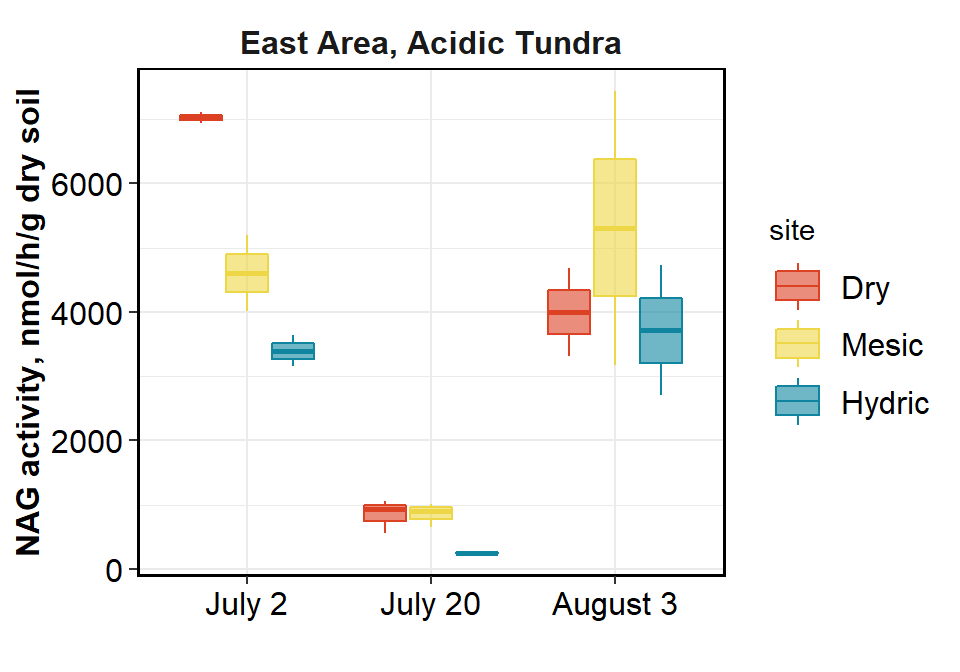

```r
all_enzymes_wider_2021_fig_east_nag =
  all_enzymes_wider_2021 %>%
  filter(area == "East") %>%
    mutate(area = recode(area, "East" = "East Area, Acidic Tundra")) %>%
  ggplot()+
  geom_boxplot(aes(x = date, y = NAG, fill = site, color = site), alpha = 0.6)+
  labs(y = "NAG activity, nmol/h/g dry soil",
       x = " ")+
  scale_fill_manual(values = rev((PNWColors::pnw_palette("Bay", 3))))+
  scale_color_manual(values = rev((PNWColors::pnw_palette("Bay", 3))))+
 # scale_x_date(date_labels = "%b-%d")+
  facet_grid(.~area)+
  theme_im()+
  theme(legend.position = "right")

plot(all_enzymes_wider_2021_fig_east_nag)
```

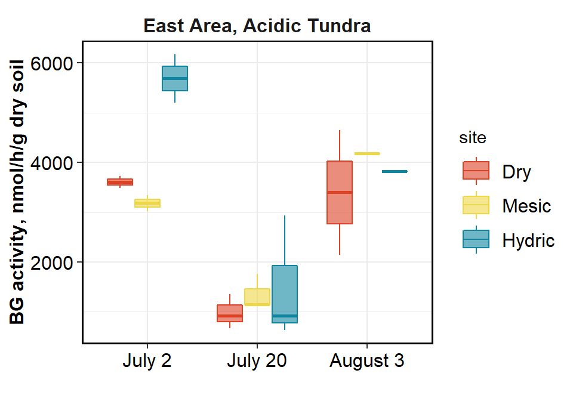

```r
ggsave("output/2021_fig_east_nag.png", plot =  all_enzymes_wider_2021_fig_east_nag, height = 3.5, width = 5)
all_enzymes_wider_2021_fig_east_bg =
  all_enzymes_wider_2021 %>%
  filter(area == "East") %>%
  mutate(area = recode(area, "East" = "East Area, Acidic Tundra")) %>%
  ggplot()+
  geom_boxplot(aes(x = date, y = BG, fill = site, color = site), alpha = 0.6)+
  labs(y = "BG activity, nmol/h/g dry soil",
       x = " ")+
  scale_fill_manual(values = rev((PNWColors::pnw_palette("Bay", 3))))+
  scale_color_manual(values = rev((PNWColors::pnw_palette("Bay", 3))))+
  # scale_x_date(date_labels = "%b-%d")+
  facet_grid(.~area)+
  theme_im()+
  theme(legend.position = "right")

plot(all_enzymes_wider_2021_fig_east_bg)
```

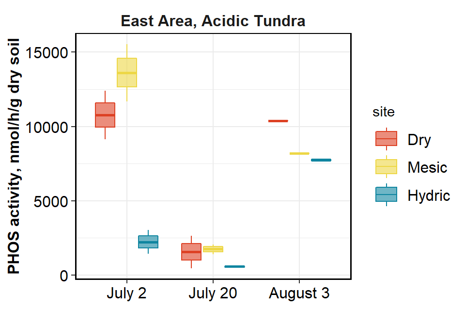

```r
ggsave("output/2021_fig_east_bg.png", plot =  all_enzymes_wider_2021_fig_east_bg, height = 3.5, width = 5)
all_enzymes_wider_2021_fig_east_phos =
  all_enzymes_wider_2021 %>%
  filter(area == "East") %>%
  mutate(area = recode(area, "East" = "East Area, Acidic Tundra")) %>%
  ggplot()+
  geom_boxplot(aes(x = date, y = PHOS, fill = site, color = site), alpha = 0.6)+
  labs(y = "PHOS activity, nmol/h/g dry soil",
       x = " ")+
  scale_fill_manual(values = rev((PNWColors::pnw_palette("Bay", 3))))+
  scale_color_manual(values = rev((PNWColors::pnw_palette("Bay", 3))))+
  # scale_x_date(date_labels = "%b-%d")+
  facet_grid(.~area)+
  theme_im()+
  theme(legend.position = "right")

plot(all_enzymes_wider_2021_fig_east_phos)
```

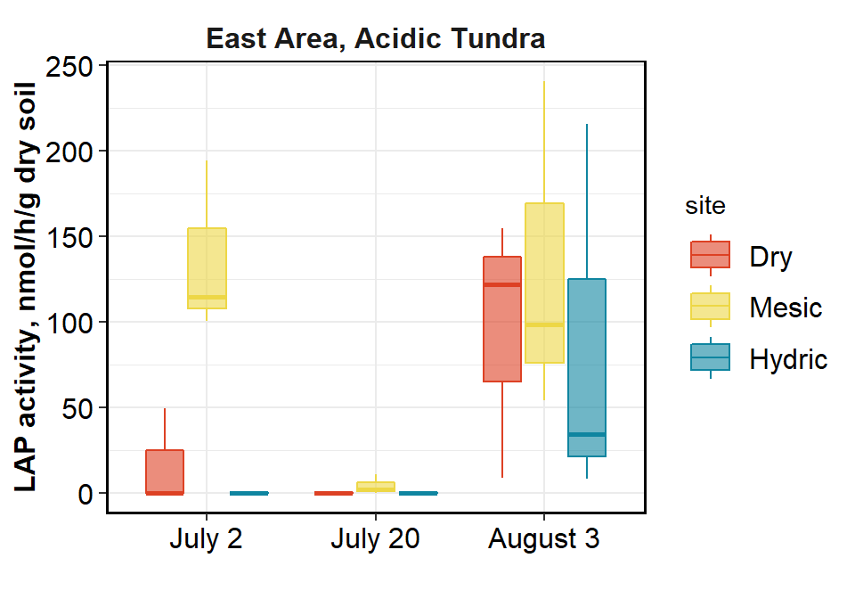

```r
ggsave("output/2021_fig_east_phos.png", plot =  all_enzymes_wider_2021_fig_east_phos, height = 3.5, width = 5)
all_enzymes_wider_2021_fig_east_lap =
  all_enzymes_wider_2021 %>%
  filter(area == "East") %>%
  mutate(area = recode(area, "East" = "East Area, Acidic Tundra")) %>%
  ggplot()+
  geom_boxplot(aes(x = date, y = LAP, fill = site, color = site), alpha = 0.6)+
  labs(y = "LAP activity, nmol/h/g dry soil",
       x = " ")+
  scale_fill_manual(values = rev((PNWColors::pnw_palette("Bay", 3))))+
  scale_color_manual(values = rev((PNWColors::pnw_palette("Bay", 3))))+
  # scale_x_date(date_labels = "%b-%d")+
  facet_grid(.~area)+
  theme_im()+
  theme(legend.position = "right")

plot(all_enzymes_wider_2021_fig_east_lap)
```

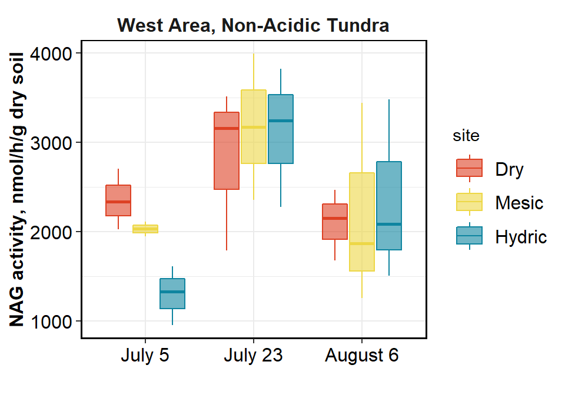

```r
ggsave("output/2021_fig_east_lap.png", plot =  all_enzymes_wider_2021_fig_east_lap, height = 3.5, width = 5)




all_enzymes_wider_2021_fig_west_nag =
  all_enzymes_wider_2021 %>%
  filter(area == "West") %>%
  mutate(area = recode(area, "West" = "West Area, Non-Acidic Tundra")) %>%
  ggplot()+
  geom_boxplot(aes(x = date, y = NAG, fill = site, color = site), alpha = 0.6)+
  labs(y = "NAG activity, nmol/h/g dry soil",
       x = " ")+
  scale_fill_manual(values = rev((PNWColors::pnw_palette("Bay", 3))))+
  scale_color_manual(values = rev((PNWColors::pnw_palette("Bay", 3))))+
  # scale_x_date(date_labels = "%b-%d")+
  facet_grid(.~area)+
  theme_im()+
  theme(legend.position = "right")

plot(all_enzymes_wider_2021_fig_west_nag)
```

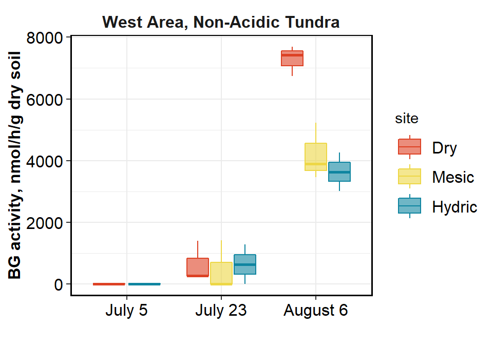

```r
ggsave("output/2021_fig_west_nag.png", plot =  all_enzymes_wider_2021_fig_west_nag, height = 3.5, width = 5)
all_enzymes_wider_2021_fig_west_bg =
  all_enzymes_wider_2021 %>%
  filter(area == "West") %>%
  mutate(area = recode(area, "West" = "West Area, Non-Acidic Tundra")) %>%
  ggplot()+
  geom_boxplot(aes(x = date, y = BG, fill = site, color = site), alpha = 0.6)+
  labs(y = "BG activity, nmol/h/g dry soil",
       x = " ")+
  scale_fill_manual(values = rev((PNWColors::pnw_palette("Bay", 3))))+
  scale_color_manual(values = rev((PNWColors::pnw_palette("Bay", 3))))+
  # scale_x_date(date_labels = "%b-%d")+
  facet_grid(.~area)+
  theme_im()+
  theme(legend.position = "right")

plot(all_enzymes_wider_2021_fig_west_bg)
```

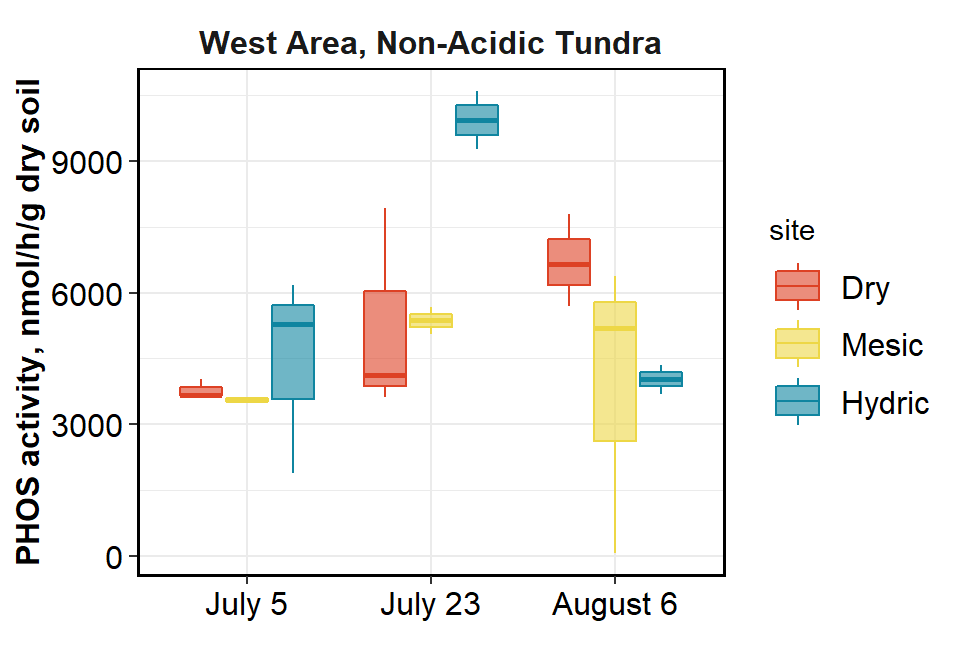

```r
ggsave("output/2021_fig_west_bg.png", plot =  all_enzymes_wider_2021_fig_west_bg, height = 3.5, width = 5)
all_enzymes_wider_2021_fig_west_phos =
  all_enzymes_wider_2021 %>%
  filter(area == "West") %>%
  mutate(area = recode(area, "West" = "West Area, Non-Acidic Tundra")) %>%
  ggplot()+
  geom_boxplot(aes(x = date, y = PHOS, fill = site, color = site), alpha = 0.6)+
  labs(y = "PHOS activity, nmol/h/g dry soil",
       x = " ")+
  scale_fill_manual(values = rev((PNWColors::pnw_palette("Bay", 3))))+
  scale_color_manual(values = rev((PNWColors::pnw_palette("Bay", 3))))+
  # scale_x_date(date_labels = "%b-%d")+
  facet_grid(.~area)+
  theme_im()+
  theme(legend.position = "right")

plot(all_enzymes_wider_2021_fig_west_phos)
```

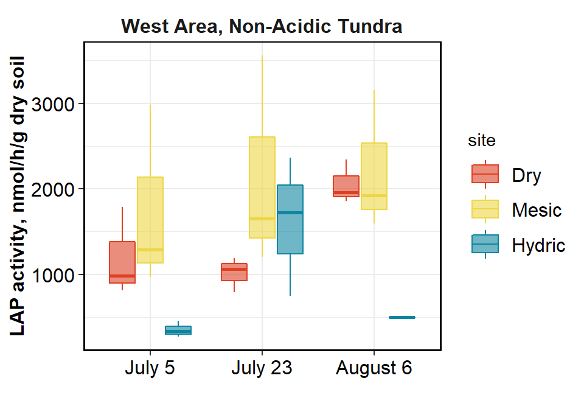

```r
ggsave("output/2021_fig_west_phos.png", plot =  all_enzymes_wider_2021_fig_west_phos, height = 3.5, width = 5)
all_enzymes_wider_2021_fig_west_lap =
  all_enzymes_wider_2021 %>%
  filter(area == "West") %>%
  mutate(area = recode(area, "West" = "West Area, Non-Acidic Tundra")) %>%
  ggplot()+
  geom_boxplot(aes(x = date, y = LAP, fill = site, color = site), alpha = 0.6)+
  labs(y = "LAP activity, nmol/h/g dry soil",
       x = " ")+
  scale_fill_manual(values = rev((PNWColors::pnw_palette("Bay", 3))))+
  scale_color_manual(values = rev((PNWColors::pnw_palette("Bay", 3))))+
  # scale_x_date(date_labels = "%b-%d")+
  facet_grid(.~area)+
  theme_im()+
  theme(legend.position = "right")

plot(all_enzymes_wider_2021_fig_west_lap)
```

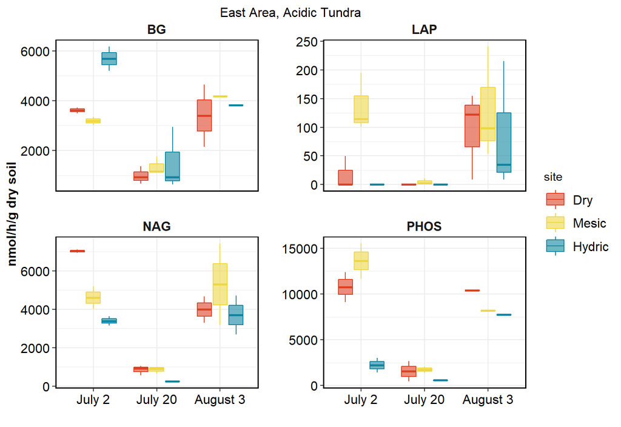

```r
ggsave("output/2021_fig_west_lap.png", plot =  all_enzymes_wider_2021_fig_west_lap, height = 3.5, width = 5)
allenzymes_east_fig =
all_enzymes_notwider_2021 %>%
  filter(area == "East") %>%
  mutate(area = recode(area, "East" = "East Area, Acidic Tundra")) %>%
  ggplot()+
  geom_boxplot(aes(x = date, y = enzyme_activity, fill = site, color = site), alpha = 0.6)+
  labs(y = "nmol/h/g dry soil",
       x = " ",
       subtitle = "East Area, Acidic Tundra")+
  scale_fill_manual(values = rev((PNWColors::pnw_palette("Bay", 3))))+
  scale_color_manual(values = rev((PNWColors::pnw_palette("Bay", 3))))+
  # scale_x_date(date_labels = "%b-%d")+
  facet_wrap(enzyme_type~., scale = "free_y")+
  theme_im()+
  theme(legend.position = "right")

plot(allenzymes_east_fig)
```

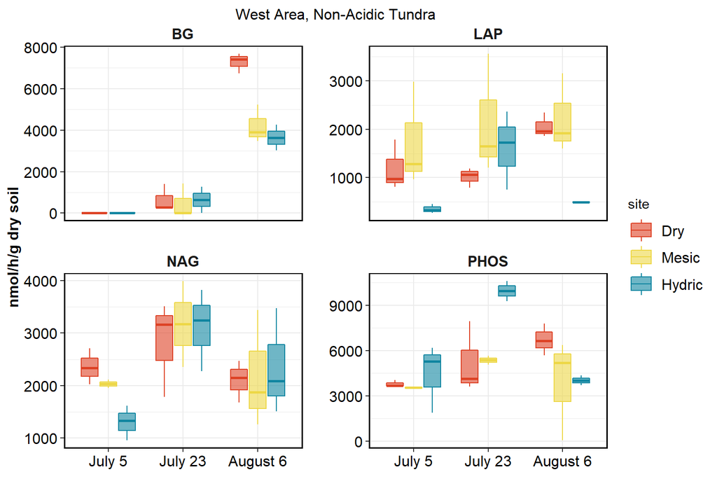

```r
ggsave("output/allenzymes_east_fig2021.png", plot =  allenzymes_east_fig, height = 5.5, width = 8)
allenzymes_west_fig =
  all_enzymes_notwider_2021 %>%
  filter(area == "West") %>%
  #mutate(area = recode(area, "East" = "East Area, Acidic Tundra")) %>%
  ggplot()+
  geom_boxplot(aes(x = date, y = enzyme_activity, fill = site, color = site), alpha = 0.6)+
  labs(y = "nmol/h/g dry soil",
       x = " ",
       subtitle = "West Area, Non-Acidic Tundra")+
  scale_fill_manual(values = rev((PNWColors::pnw_palette("Bay", 3))))+
  scale_color_manual(values = rev((PNWColors::pnw_palette("Bay", 3))))+
  # scale_x_date(date_labels = "%b-%d")+
  facet_wrap(enzyme_type~., scale = "free_y")+
  theme_im()+
  theme(legend.position = "right")

plot(allenzymes_west_fig)
```

```r
ggsave("output/allenzymes_west_fig2021.png", plot =  allenzymes_west_fig, height = 5.5, width = 8)
```